# Stock Market Prediction Using Textual and Numerical Analysis

Atmik

3/15/2022

## Using ARIMA Model to Predict the Movement of Stock Market in the Near Future

Importing Libraries

```r
library(tidyverse)
library(tseries)
```

```r
library(forecast)
library(ggplot2)
library(caTools)
library(rpart)
library(syuzhet)
library(randomForest)
```

Reading the file and Data Preprocessing

```r
df <- read.csv(file.choose())
start <- which(rownames(df) == "January-2012")
end <- which(rownames(df) == "December-2019")
df <- df[start:end,]
df$MonthsNew <- rownames(df)
df <- df[,c(4,6)]
colnames(df) <- c("Close", "Month")
df<- df[,c(2,1)]
rownames(df) <- NULL
df %>% separate(Month, c("Month","Year"), sep = "-" )
```

```
##        Month Year    Close
## 1    January 2012 17193.55
## 2   February 2012 17752.68
## 3      March 2012 17404.20
## 4      April 2012 17318.81
## 5        May 2012 16218.53
## 6       June 2012 17429.98
## 7       July 2012 17236.18
## 8     August 2012 17429.56
## 9  September 2012 18762.74
## 10   October 2012 18505.38
## 11  November 2012 19339.90
## 12  December 2012 19426.71
## 13   January 2013 19894.98
## 14  February 2013 18861.54
```

[output cut: 82 more lines]

Converting into Time Series

```r
ts <- ts(df$Close, freq = 12, start = c(2012, 1), end = c(2019, 12))
ts
```

```
##           Jan      Feb      Mar      Apr      May      Jun      Jul      Aug
## 2012 17193.55 17752.68 17404.20 17318.81 16218.53 17429.98 17236.18 17429.56
## 2013 19894.98 18861.54 18835.77 19504.18 19760.30 19395.81 19345.70 18619.72
## 2014 20513.85 21120.12 22386.27 22417.80 24217.34 25413.78 25894.97 26638.11
## 2015 29182.95 29361.50 27957.49 27011.31 27828.44 27780.83 28114.56 26283.09
## 2016 24870.69 23002.00 25341.86 25606.62 26667.96 26999.72 28051.86 28452.17
## 2017 27655.96 28743.32 29620.50 29918.40 31145.80 30921.61 32514.94 31730.49
## 2018 35965.02 34184.04 32968.68 35160.36 35322.38 35423.48 37606.58 38645.07
## 2019 36256.69 35867.44 38672.91 39031.55 39714.20 39394.64 37481.12 37332.79
##           Sep      Oct      Nov      Dec
## 2012 18762.74 18505.38 19339.90 19426.71
## 2013 19379.77 21164.52 20791.93 21170.68
## 2014 26630.51 27865.83 28693.99 27499.42
## 2015 26154.83 26656.83 26145.67 26117.54
## 2016 27865.96 27930.21 26652.81 26626.46
## 2017 31283.72 33213.13 33149.35 34056.83
## 2018 36227.14 34442.05 36194.30 36068.33
## 2019 38667.33 40129.05 40793.81 41253.74
```

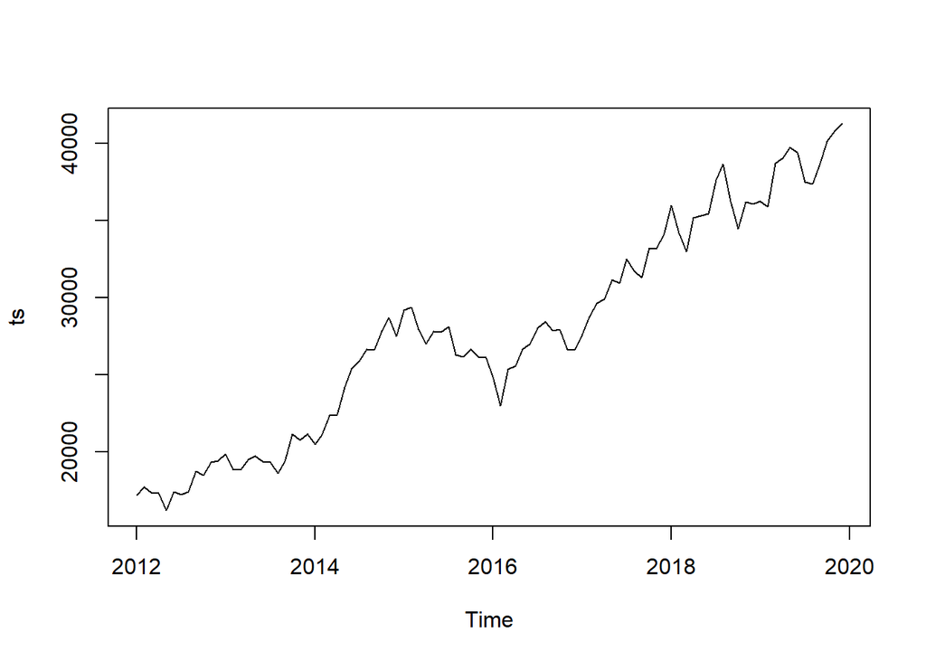

```r
plot(ts)
```

Making the Time Series Stationary and Plotting Different Components of Time Series

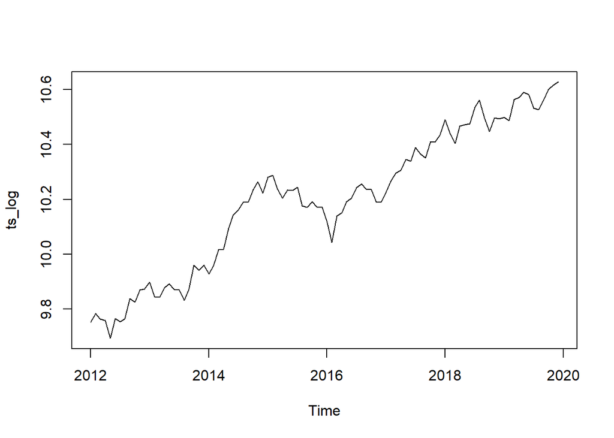

```r
ts_log <- log(ts)
plot(ts_log)
```

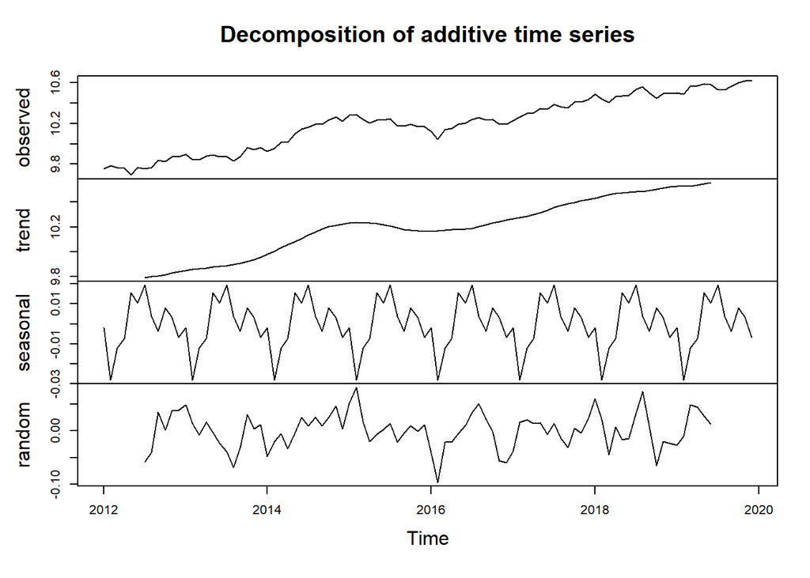

```r
decomp <- decompose(ts_log)
plot(decomp)
```

Findng the Best Fittting ARIMA Model

```r
model <- auto.arima(ts_log)
model
```

```
## Series: ts_log
## ARIMA(0,1,0)(1,0,0)[12] with drift
##
## Coefficients:
##          sar1   drift
##       -0.2209  0.0091
## s.e.   0.1038  0.0031
##
## sigma^2 = 0.001367:  log likelihood = 179.21
## AIC=-352.42   AICc=-352.16   BIC=-344.76
```

Plotting ACF and PACF Graphs for the Best Fittting ARIMA Model

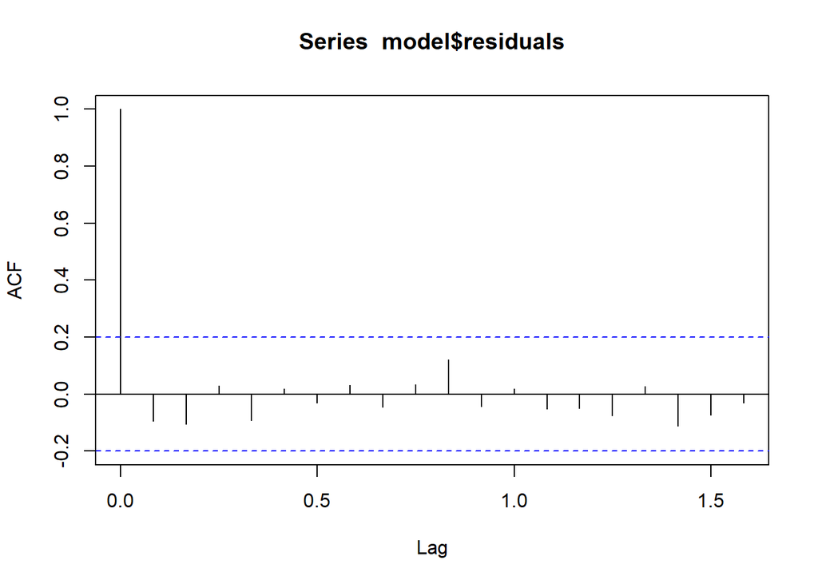

```r
acf(model$residuals)
```

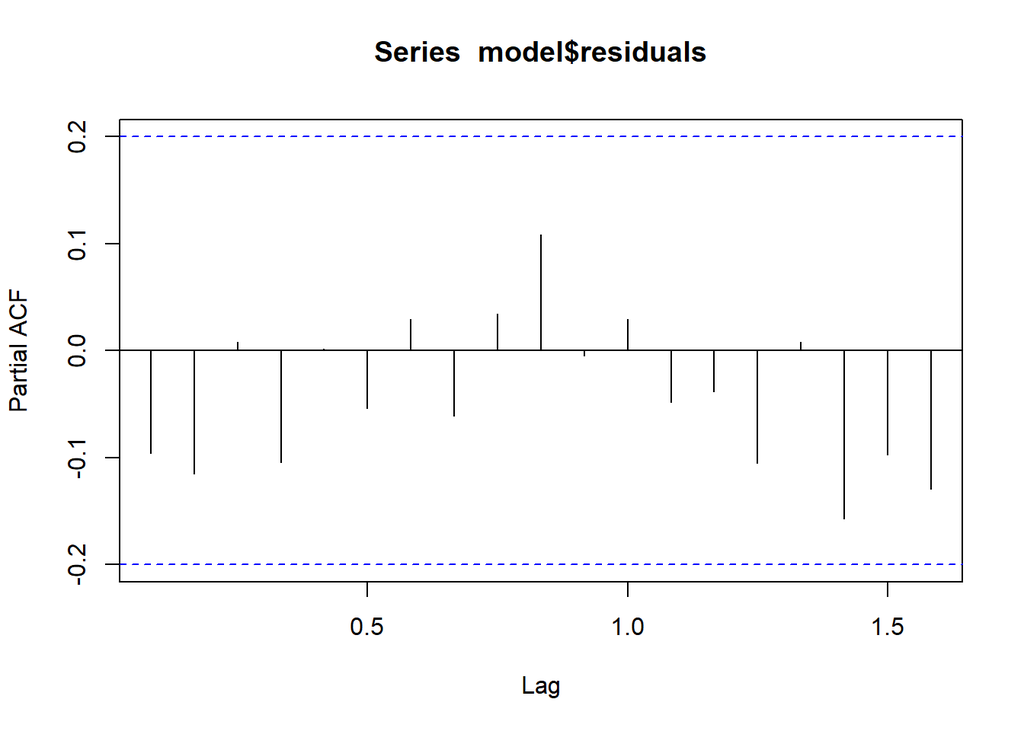

```r
pacf(model$residuals)
```

```r
Box.test(model$residuals, type = 'Ljung-Box')
```

```
##
##  Box-Ljung test
##
## data:  model$residuals
## X-squared = 0.91306, df = 1, p-value = 0.3393
```

```r
adf.test(diff(ts_log))
```

```
##
##  Augmented Dickey-Fuller Test
##
## data:  diff(ts_log)
## Dickey-Fuller = -4.4926, Lag order = 4, p-value = 0.01
## alternative hypothesis: stationary
```

Forecasting and Plotting the Forecast

```r
f <- forecast(model, 12)
f
```

```
##          Point Forecast    Lo 80    Hi 80    Lo 95    Hi 95
## Jan 2020       10.63745 10.59007 10.68484 10.56498 10.70992
## Feb 2020       10.65094 10.58393 10.71795 10.54845 10.75342
## Mar 2020       10.64541 10.56333 10.72748 10.51989 10.77093
## Apr 2020       10.65447 10.55970 10.74924 10.50953 10.79941
## May 2020       10.66175 10.55579 10.76770 10.49970 10.82379
## Jun 2020       10.67463 10.55856 10.79070 10.49712 10.85215
## Jul 2020       10.69673 10.57137 10.82210 10.50500 10.88847
## Aug 2020       10.70871 10.57469 10.84274 10.50374 10.91369
## Sep 2020       10.71206 10.56990 10.85421 10.49465 10.92947
## Oct 2020       10.71497 10.56512 10.86481 10.48580 10.94414
## Nov 2020       10.72244 10.56528 10.87960 10.48209 10.96280
## Dec 2020       10.73107 10.56692 10.89522 10.48003 10.98211
```

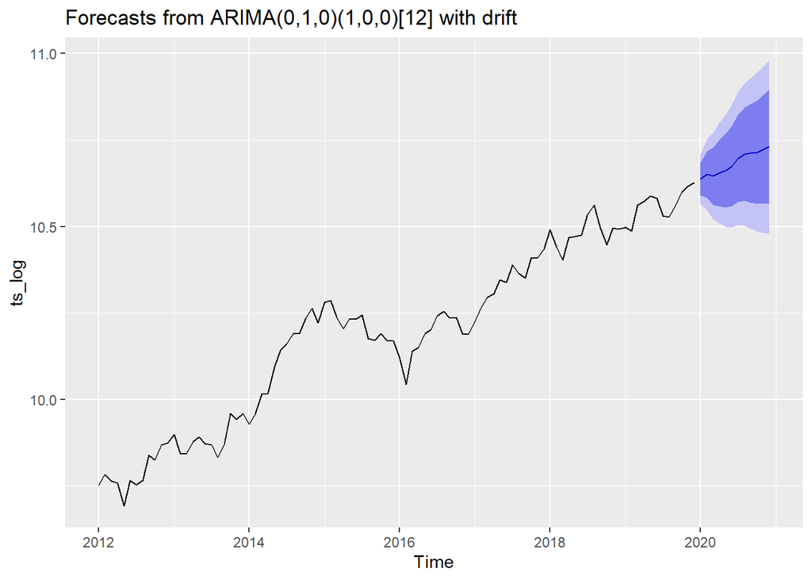

```r
autoplot(f)
```

## Using Natural Language Processing to Gauge the Effect of News Headlines on Stock Market

Importing the Dataset

```r
news <- read.csv(file.choose(),stringsAsFactors = F)
news2 <- news
```

Data Preprocessing

```r
news$publish_date <- as.Date(as.character(news$publish_date), "%Y%m%d")
news$headline_category <- NULL
news <- news[news$publish_date > as.Date("2012-01-01") & news$publish_date < as.Date("2019-12-31"),]
news <- separate(news, publish_date, c("Year","Month","Day"), "-")
news$Day <- NULL
news$time <- paste(news$Month, "-", news$Year)
news$Month <- NULL
news$Year <- NULL
news2 <- news
```

Collapsing the Dataframe into Monthly News

```r
news3 <- news %>% group_by(time) %>% summarise(headline_text=paste(headline_text, collapse = " "))
```

Sentiment Analysis of the News Headlines

```r
text <- as.character(news3$headline_text)
class(news3$headline_text)
```

```
## [1] "character"
```

```r
s <- get_nrc_sentiment(text)
head(s)
```

```
##   anger anticipation disgust fear joy sadness surprise trust negative positive
## 1   475          439     336  602 332     482      254   562     1168     1003
## 2   497          441     356  590 346     461      251   586     1200     1070
## 3   515          439     342  622 350     478      269   590     1172     1069
## 4   519          463     359  637 371     492      276   614     1240     1099
## 5   507          460     351  643 356     483      279   604     1230     1111
## 6   509          458     361  627 364     490      265   631     1238     1107
```

Merging the Stock Closing Index and News Headlines Dataframe

```r
final <- data.frame(df$Month, s, df$Close)
final$PrevClose[2:96]<- final$df.Close[1:95]
final$PrevClose[1] <- 15454.92
final$Change <- (final$df.Close - final$PrevClose)*100/final$PrevClose
final$Change <-   round(final$Change, 2)
final$Class <- ifelse(final$Change > 0, 1 , 0)
head(final,10)
```

```
##          df.Month anger anticipation disgust fear joy sadness surprise trust
## 1    January-2012   475          439     336  602 332     482      254   562
## 2   February-2012   497          441     356  590 346     461      251   586
## 3      March-2012   515          439     342  622 350     478      269   590
## 4      April-2012   519          463     359  637 371     492      276   614
## 5        May-2012   507          460     351  643 356     483      279   604
## 6       June-2012   509          458     361  627 364     490      265   631
## 7       July-2012   539          463     395  666 367     499      271   609
## 8     August-2012   440          398     324  539 308     422      234   531
## 9  September-2012   490          430     340  596 350     470      250   587
## 10   October-2012   485          434     353  606 347     478      267   581
##    negative positive df.Close PrevClose Change Class
## 1      1168     1003 17193.55  15454.92  11.25     1
## 2      1200     1070 17752.68  17193.55   3.25     1
## 3      1172     1069 17404.20  17752.68  -1.96     0
## 4      1240     1099 17318.81  17404.20  -0.49     0
## 5      1230     1111 16218.53  17318.81  -6.35     0
## 6      1238     1107 17429.98  16218.53   7.47     1
## 7      1269     1096 17236.18  17429.98  -1.11     0
## 8      1108      945 17429.56  17236.18   1.12     1
## 9      1167     1034 18762.74  17429.56   7.65     1
## 10     1186     1030 18505.38  18762.74  -1.37     0
```

Feature Selection, Scaling and Factorization

```r
final2 <- final[,c(-1,-12:-14)]
final2[,1:10] <- scale(final2[,1:10])
final2$Class <- factor(final2$Class)
class(final2$Class)
```

```
## [1] "factor"
```

```r
head(final2)
```

```
##        anger anticipation     disgust        fear         joy      sadness
## 1 -1.0313159  -0.05373090 -1.27113299 -0.65975196 -0.70551653 -0.299767546
## 2 -0.1818076   0.03676325 -0.14018983 -1.03177069 -0.01237748 -1.099147668
## 3  0.5132446  -0.05373090 -0.93185004 -0.03972075  0.18566224 -0.452030426
## 4  0.6677006   1.03219894  0.02945164  0.42530266  1.22537081  0.080889655
## 5  0.2043325   0.89645771 -0.42292562  0.61131202  0.48272184 -0.261701826
## 6  0.2815605   0.80596356  0.14254596  0.11528705  0.87880129  0.004758215
##     surprise       trust   negative   positive Class
## 1 -0.5202548 -0.98731806 -0.7863307 -0.8998395     1
## 2 -0.7274932 -0.16072620 -0.2350737  0.2947462     1
## 3  0.5159373 -0.02296089 -0.7174235  0.2769166     0
## 4  0.9994936  0.80363098  0.4539974  0.8118057     0
## 5  1.2067320  0.45921770  0.2817296  1.0257613     0
## 6  0.2396194  1.38913355  0.4195438  0.9544428     1
```

Splitting Data into Training and Test Data Sets

```r
split <- sample.split(final2$Class, SplitRatio = 0.75)
training <- subset(final2, split == T)
test <- subset(final2, split == F)
colnames(final2)
```

```
##  [1] "anger"        "anticipation" "disgust"      "fear"         "joy"
##  [6] "sadness"      "surprise"     "trust"        "negative"     "positive"
## [11] "Class"
```

Logistic Regression Classifier

```r
lr_classifier <- glm(formula = Class ~ . , family = binomial, data = training )
summary(lr_classifier)
```

```
##
## Call:
## glm(formula = Class ~ ., family = binomial, data = training)
##
## Deviance Residuals:
##     Min       1Q   Median       3Q      Max
## -2.1131  -0.9926   0.5074   0.8790   1.7563
##
## Coefficients:
##              Estimate Std. Error z value Pr(>|z|)
## (Intercept)    0.5252     0.2829   1.856   0.0634 .
## anger         -0.3487     0.8714  -0.400   0.6890
## anticipation   1.4003     0.7204   1.944   0.0519 .
## disgust        1.5969     0.7254   2.201   0.0277 *
## fear          -1.1299     1.0764  -1.050   0.2938
## joy           -0.3200     0.7591  -0.422   0.6734
## sadness        0.1537     0.7551   0.204   0.8387
## surprise       0.3589     0.6132   0.585   0.5584
## trust          1.3585     1.0064   1.350   0.1771
## negative      -1.9655     1.0055  -1.955   0.0506 .
## positive      -1.6062     1.3360  -1.202   0.2293
## ---
## Signif. codes:  0 '***' 0.001 '**' 0.01 '*' 0.05 '.' 0.1 ' ' 1
##
## (Dispersion parameter for binomial family taken to be 1)
##
##     Null deviance: 97.074  on 71  degrees of freedom
## Residual deviance: 80.526  on 61  degrees of freedom
## AIC: 102.53
##
## Number of Fisher Scoring iterations: 4
```

```r
prob <- predict(lr_classifier, type = 'response', newdata = test[-11])
prob
```

```
##        10        19        29        40        45        46        52        54
## 0.8427388 0.6880995 0.8271237 0.9422668 0.4474759 0.7536168 0.4890011 0.4183131
##        58        59        63        66        68        70        72        74
## 0.2054137 0.4949917 0.7591099 0.7105544 0.6345630 0.4488202 0.9179183 0.8388696
##        77        78        82        83        86        93        94        96
## 0.5458893 0.2287434 0.8694612 0.1026271 0.2821741 0.2313967 0.1783488 0.9807429
```

```r
y <- ifelse(prob > 0.5, 1, 0)
y
```

```
## 10 19 29 40 45 46 52 54 58 59 63 66 68 70 72 74 77 78 82 83 86 93 94 96
##  1  1  1  1  0  1  0  0  0  0  1  1  1  0  1  1  1  0  1  0  0  0  0  1
```

Confusion Matrix for Logistic Regression Classifier

```r
lr_cm <- table(test$Class, y)
lr_cm
```

```
##    y
##     0 1
##   0 3 7
##   1 8 6
```

Decision Tree Classifier

```r
dtclassifier <- rpart(formula = Class ~ . , data = training)

dt_y <- predict(dtclassifier, newdata = test[-11], type = 'class')
dt_y
```

```
## 10 19 29 40 45 46 52 54 58 59 63 66 68 70 72 74 77 78 82 83 86 93 94 96
##  0  1  1  1  0  0  0  1  0  1  1  0  1  1  1  1  1  0  1  0  1  1  1  1
## Levels: 0 1
```

Confusion Matrix for Decision Tree Classifier

```r
cm <- table(test$Class, dt_y)
cm
```

```
##    dt_y
##     0 1
##   0 3 7
##   1 5 9
```

Random Forest Classifier

```r
rf_classifier <- randomForest(x=training[-11], y=training$Class, ntree = 300)

rf_y <- predict(rf_classifier, newdata = test[-11])
rf_y
```

```
## 10 19 29 40 45 46 52 54 58 59 63 66 68 70 72 74 77 78 82 83 86 93 94 96
##  0  1  1  1  0  1  0  1  0  1  1  0  1  1  1  1  1  1  1  0  1  1  1  1
## Levels: 0 1
```

Confusion Matrix for Random Forest Classifier

```r
cm <- table(test$Class, rf_y)
cm
```

```
##    rf_y
##      0  1
##   0  3  7
##   1  3 11
```

*We see the Random Forest Classifier at 300 trees gives the best output.*

### ————————————————————————————————————————————————————